# Comparing immune cell response in PAD4 KO cells

## Introduction and Background

```r
library(tidyverse)
library(lmerTest)
library(ggResidpanel)
```

Import data, and remove Mean and SD rows. There are a total of 6 samples. The first 3 samples are WT; the next 3 samples are PAD4KO.

Also, arrange columns as (1) identifiers, (2) Experimental factors, (3) response.

```r
immune1 <- read_csv("data/Overview_20220413_CD45freq_recomp_counts.csv") %>%
  select(1:7) %>%
  rename(specimen = "...1") %>%
  filter(str_detect(specimen, "PAD4")) %>%
  mutate(group = c(rep("WT",3), rep("PAD4KO",3)))

colnames(immune1) <- c("specimen", "CD45pos", "immature_neutrophils", "mature_neutrophils", "bcells", "CD4posTcells", "CD4negTcells", "group")

immune1 <- immune1 %>%
  select(specimen, group,CD45pos, immature_neutrophils, mature_neutrophils, bcells, CD4posTcells, CD4negTcells )

glimpse(immune1)
```

```
## Rows: 6
## Columns: 8
## $ specimen             <chr> "PAD4_Tube_001_045.fcs", "PAD4_Tube_002_046.fcs",…
## $ group                <chr> "WT", "WT", "WT", "PAD4KO", "PAD4KO", "PAD4KO"
## $ CD45pos              <dbl> 32899, 40705, 42186, 36425, 24016, 31148
## $ immature_neutrophils <dbl> 13, 4, 8, 16, 9, 8
## $ mature_neutrophils   <dbl> 123, 71, 123, 61, 76, 77
## $ bcells               <dbl> 18683, 21138, 22036, 19675, 13608, 17236
## $ CD4posTcells         <dbl> 5065, 7083, 7285, 6490, 4435, 5665
## $ CD4negTcells         <dbl> 5193, 7328, 6945, 5383, 3296, 4408
```

For each sample, we would like to calculate Percent CD45pos cells for each immune cell type. Suggested approach: re-structure the data using pivot_longer() and then calculate percentages in 1 line.Notice that since percentages should add up to 100, first create new variable called Other = CD45pos - all_other_named_types.

```r
immune1_long <- immune1 %>%
  mutate(Other = CD45pos - rowSums(.[4:8])) %>%
  pivot_longer(cols = c(4:9), names_to = "cell_type",
               values_to = "count") %>%
  mutate(percent = count/CD45pos*100)
```

Now create a stacked column graph for each specimen:

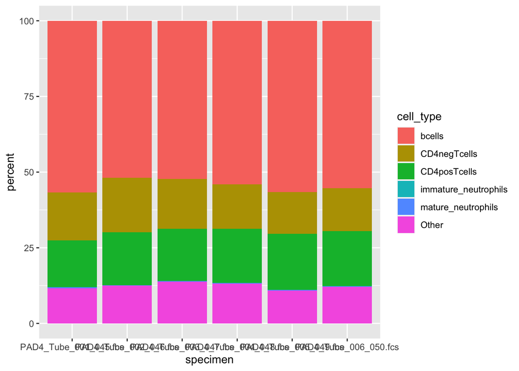

```r
ggplot(immune1_long, aes(x = specimen, y = percent, fill = cell_type))+
  geom_col()
```

Re-arrange the stacks by re-ordering the levels of Cell_type. Also, relabel the x-axis to be able to see which samples are WT and PAD4KO. The stacks are ordered so that Level 1 is on the top and Level 6 is on the bottom.

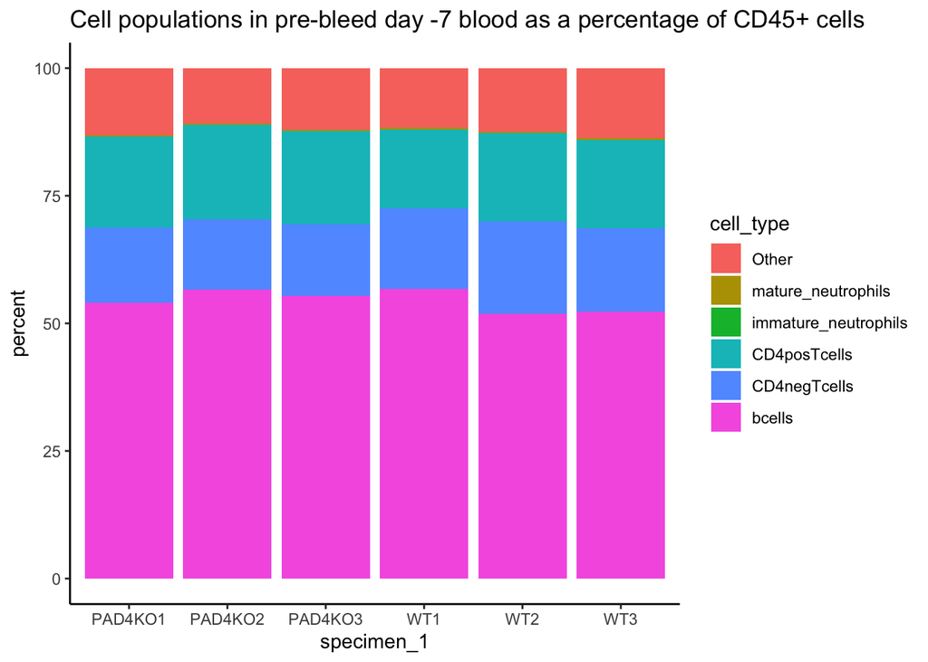

```r
immune1_long <- immune1_long %>%
  mutate(cell_type = factor(cell_type, levels = c("Other",
                                                  "mature_neutrophils",
                                                  "immature_neutrophils",
                                                  "CD4posTcells",
                                                  "CD4negTcells",
                                                  "bcells")),
         specimen_1 = rep(c("WT1","WT2","WT3","PAD4KO1","PAD4KO2","PAD4KO3"),
                          each = 6))

ggplot(immune1_long, aes(x = specimen_1, y = percent, fill = cell_type))+
  geom_col() +
  ggtitle("Cell populations in pre-bleed day -7 blood as a percentage of CD45+ cells") +
  theme_classic()
```

We can also average them first by group, and create a stacked column chart for each group (WT vs PAD4KO).

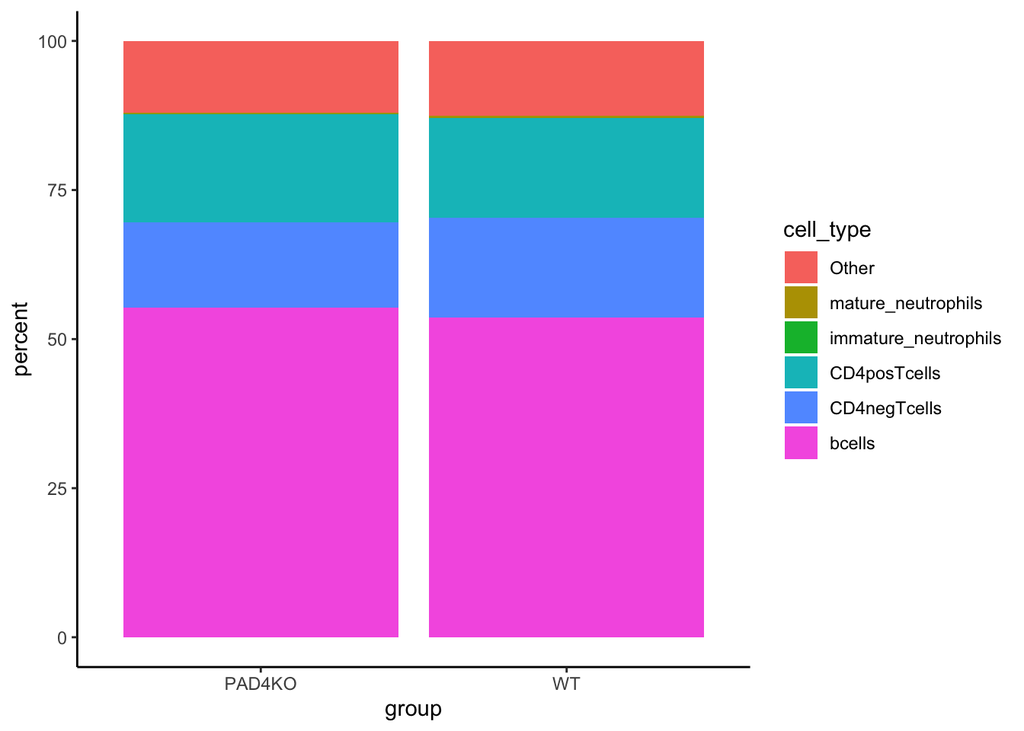

```r
immune1_avg <- immune1_long %>%
  group_by(cell_type, group) %>%
  summarise(percent = mean(percent), .groups = "drop")


  ggplot(immune1_avg, aes(x = group, y = percent, fill = cell_type))+
  geom_col() +
  theme_classic()
```

```r
  immune1_avg
```

```
## # A tibble: 12 × 3
##    cell_type            group  percent
##    <fct>                <chr>    <dbl>
##  1 Other                PAD4KO 12.0
##  2 Other                WT     12.6
##  3 mature_neutrophils   PAD4KO  0.244
##  4 mature_neutrophils   WT      0.280
##  5 immature_neutrophils PAD4KO  0.0357
##  6 immature_neutrophils WT      0.0228
##  7 CD4posTcells         PAD4KO 18.2
##  8 CD4posTcells         WT     16.7
##  9 CD4negTcells         PAD4KO 14.2
## 10 CD4negTcells         WT     16.8
## 11 bcells               PAD4KO 55.3
## 12 bcells               WT     53.7
```

The easiest way to compare statistically is to choose a cell type and compare the percentage of that cell type. If you want to be more sophisticated, you can fit a model for count data (negative binomial model) and then we can compare the cell type composition. Or we can compare the composition using compositional data analysis where we transform the compositional data to data that is multivariate normal. Personally I would choose a model that people in your field are familiar with.

```r
lm1 <- lmer(sqrt(percent)~cell_type*group + (1|specimen), data = immune1_long)
```

```
## boundary (singular) fit: see ?isSingular
```

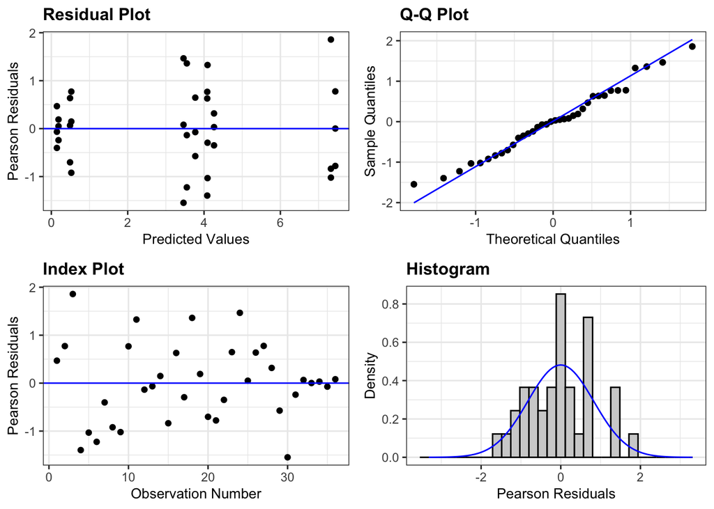

```r
resid_panel(lm1)
```

```r
anova(lm1)
```

```
## Type III Analysis of Variance Table with Satterthwaite's method
##                  Sum Sq Mean Sq NumDF DenDF   F value  Pr(>F)
## cell_type       212.847  42.569     5    24 3249.4186 < 2e-16 ***
## group             0.003   0.003     1    24    0.2107 0.65034
## cell_type:group   0.234   0.047     5    24    3.5793 0.01469 *
## ---
## Signif. codes:  0 '***' 0.001 '**' 0.01 '*' 0.05 '.' 0.1 ' ' 1
```

Estimated percents for each group/cell_type

```r
library(emmeans)
emmeans(lm1, pairwise~ group|cell_type, type = "response")
```

```
## Note: Use 'contrast(regrid(object), ...)' to obtain contrasts of back-transformed estimates
```

```
## $emmeans
## cell_type = Other:
##  group  response     SE df lower.CL upper.CL
##  PAD4KO  11.9877 0.4576 24 11.06187  12.9507
##  WT      12.5928 0.4690 24 11.64338  13.5793
##
## cell_type = mature_neutrophils:
##  group  response     SE df lower.CL upper.CL
##  PAD4KO   0.2398 0.0647 24  0.12480   0.3919
##  WT       0.2736 0.0691 24  0.14949   0.4348
##
## cell_type = immature_neutrophils:
##  group  response     SE df lower.CL upper.CL
##  PAD4KO   0.0353 0.0248 24  0.00264   0.1051
##  WT       0.0211 0.0192 24  0.00008   0.0793
##
## cell_type = CD4posTcells:
##  group  response     SE df lower.CL upper.CL
##  PAD4KO  18.1562 0.5632 24 17.01255  19.3371
##  WT      16.6756 0.5397 24 15.58028  17.8081
##
## cell_type = CD4negTcells:
##  group  response     SE df lower.CL upper.CL
##  PAD4KO  14.2148 0.4983 24 13.20498  15.2618
##  WT      16.7373 0.5407 24 15.63999  17.8719
##
## cell_type = bcells:
##  group  response     SE df lower.CL upper.CL
##  PAD4KO  55.3324 0.9831 24 53.32198  57.3801
##  WT      53.6287 0.9679 24 51.64968  55.6448
##
## Degrees-of-freedom method: kenward-roger
## Confidence level used: 0.95
## Intervals are back-transformed from the sqrt scale
##
## $contrasts
## cell_type = Other:
##  contrast    estimate     SE df t.ratio p.value
##  PAD4KO - WT  -0.0863 0.0935 24  -0.923  0.3650
##
## cell_type = mature_neutrophils:
##  contrast    estimate     SE df t.ratio p.value
##  PAD4KO - WT  -0.0334 0.0935 24  -0.357  0.7242
##
## cell_type = immature_neutrophils:
##  contrast    estimate     SE df t.ratio p.value
##  PAD4KO - WT   0.0426 0.0935 24   0.456  0.6526
##
## cell_type = CD4posTcells:
##  contrast    estimate     SE df t.ratio p.value
##  PAD4KO - WT   0.1774 0.0935 24   1.899  0.0697
##
## cell_type = CD4negTcells:
##  contrast    estimate     SE df t.ratio p.value
##  PAD4KO - WT  -0.3209 0.0935 24  -3.434  0.0022
##
## cell_type = bcells:
##  contrast    estimate     SE df t.ratio p.value
##  PAD4KO - WT   0.1154 0.0935 24   1.235  0.2288
##
## Note: contrasts are still on the sqrt scale
## Degrees-of-freedom method: kenward-roger
```

We can fit a model to individual cell types. Check that they are consistent with the larger model. For example:

```r
lm_CD4neg <- lm(percent~group, data = immune1_long %>%
            filter(cell_type == "CD4negTcells"))
#resid_panel(lm2)
anova(lm_CD4neg)
```

```
## Analysis of Variance Table
##
## Response: percent
##           Df Sum Sq Mean Sq F value  Pr(>F)
## group      1 9.6163  9.6163  12.227 0.02497 *
## Residuals  4 3.1458  0.7864
## ---
## Signif. codes:  0 '***' 0.001 '**' 0.01 '*' 0.05 '.' 0.1 ' ' 1
```

```r
emmeans(lm_CD4neg, pairwise~group)
```

```
## $emmeans
##  group  emmean    SE df lower.CL upper.CL
##  PAD4KO   14.2 0.512  4     12.8     15.6
##  WT       16.8 0.512  4     15.3     18.2
##
## Confidence level used: 0.95
##
## $contrasts
##  contrast    estimate    SE df t.ratio p.value
##  PAD4KO - WT    -2.53 0.724  4  -3.497  0.0250
```

```r
lm_bcells <- lm(percent~group, data = immune1_long %>%
            filter(cell_type == "bcells"))
#resid_panel(lm2)
anova(lm_bcells)
```

```
## Analysis of Variance Table
##
## Response: percent
##           Df  Sum Sq Mean Sq F value Pr(>F)
## group      1  4.2658  4.2658  0.9315 0.3891
## Residuals  4 18.3173  4.5793
```

```r
emmeans(lm_bcells, pairwise~group)
```

```
## $emmeans
##  group  emmean   SE df lower.CL upper.CL
##  PAD4KO   55.3 1.24  4     51.9     58.8
##  WT       53.7 1.24  4     50.2     57.1
##
## Confidence level used: 0.95
##
## $contrasts
##  contrast    estimate   SE df t.ratio p.value
##  PAD4KO - WT     1.69 1.75  4   0.965  0.3891
```

Think about how to report your conclusions graphically or in a table.